# Lab 9 - Avoiding Overfitting by Saving a Model

## Introduction

In this notebook, we will perform classification on the Fashion MNIST (fMNIST) dataset using a fully-connected feedforward neural network implemented in Tensorflow.

## Getting the Data

```python
import pandas as pd
import numpy as np
import matplotlib.pyplot as plt
import seaborn as sns

# Loading the dataset
train_dataset = pd.read_csv('D:/Study/Machine Learning Foundation/Lab8/fashion-mnist_train.csv')
test_dataset = pd.read_csv('D:/Study/Machine Learning Foundation/Lab8/fashion-mnist_test.csv')

# Tip from Assignment instruction: load the data into numpy arrays
train_images = train_dataset.iloc[:, 1:].to_numpy()
train_labels = train_dataset.iloc[:, 0].to_numpy()
test_images = test_dataset.iloc[:, 1:].to_numpy()
test_labels = test_dataset.iloc[:, 0].to_numpy()
```

## Data Exploration and EDA

Let's perform some exploratory data analysis on the fMNIST dataset.

```python
# Let's look at how the train dataset looks like
train_dataset.sample(10)
```

|  | label | pixel1 | pixel2 | pixel3 | pixel4 | pixel5 | pixel6 | pixel7 | pixel8 | pixel9 | ... | pixel775 | pixel776 | pixel777 | pixel778 | pixel779 | pixel780 | pixel781 | pixel782 | pixel783 | pixel784 |
| --- | --- | --- | --- | --- | --- | --- | --- | --- | --- | --- | --- | --- | --- | --- | --- | --- | --- | --- | --- | --- | --- |
| 18898 | 5 | 0 | 0 | 0 | 0 | 0 | 0 | 0 | 0 | 0 | ... | 0 | 0 | 0 | 0 | 0 | 0 | 0 | 0 | 0 | 0 |
| 24611 | 6 | 0 | 0 | 0 | 0 | 0 | 0 | 0 | 0 | 0 | ... | 87 | 0 | 0 | 0 | 0 | 0 | 0 | 0 | 0 | 0 |
| 13361 | 1 | 0 | 0 | 0 | 0 | 0 | 0 | 0 | 0 | 0 | ... | 65 | 0 | 0 | 0 | 0 | 0 | 0 | 0 | 0 | 0 |
| 23207 | 2 | 0 | 0 | 0 | 0 | 0 | 2 | 0 | 0 | 0 | ... | 1 | 0 | 73 | 126 | 99 | 0 | 0 | 0 | 0 | 0 |
| 40087 | 9 | 0 | 0 | 0 | 0 | 0 | 0 | 0 | 0 | 0 | ... | 0 | 0 | 0 | 0 | 0 | 0 | 0 | 0 | 0 | 0 |
| 40844 | 8 | 0 | 0 | 0 | 0 | 0 | 0 | 0 | 0 | 0 | ... | 0 | 0 | 0 | 0 | 0 | 0 | 0 | 0 | 0 | 0 |
| 42447 | 2 | 0 | 0 | 0 | 0 | 0 | 0 | 3 | 96 | 137 | ... | 96 | 82 | 65 | 13 | 0 | 0 | 0 | 0 | 0 | 0 |
| 53837 | 4 | 0 | 0 | 0 | 0 | 0 | 0 | 0 | 1 | 0 | ... | 0 | 3 | 0 | 0 | 206 | 151 | 91 | 0 | 0 | 0 |
| 47011 | 6 | 0 | 0 | 0 | 0 | 0 | 0 | 0 | 0 | 0 | ... | 13 | 0 | 0 | 0 | 0 | 0 | 0 | 0 | 0 | 0 |
| 5756 | 7 | 0 | 0 | 0 | 0 | 0 | 0 | 0 | 0 | 0 | ... | 0 | 0 | 0 | 0 | 0 | 0 | 0 | 0 | 0 | 0 |

10 rows × 785 columns

```python
test_dataset.sample(10)
```

|  | label | pixel1 | pixel2 | pixel3 | pixel4 | pixel5 | pixel6 | pixel7 | pixel8 | pixel9 | ... | pixel775 | pixel776 | pixel777 | pixel778 | pixel779 | pixel780 | pixel781 | pixel782 | pixel783 | pixel784 |
| --- | --- | --- | --- | --- | --- | --- | --- | --- | --- | --- | --- | --- | --- | --- | --- | --- | --- | --- | --- | --- | --- |
| 9502 | 5 | 0 | 0 | 0 | 0 | 0 | 0 | 0 | 0 | 0 | ... | 0 | 0 | 0 | 0 | 0 | 0 | 0 | 0 | 0 | 0 |
| 5732 | 4 | 0 | 0 | 0 | 0 | 0 | 0 | 0 | 0 | 0 | ... | 0 | 0 | 0 | 0 | 0 | 0 | 0 | 0 | 0 | 0 |
| 9618 | 9 | 0 | 0 | 0 | 0 | 0 | 0 | 0 | 0 | 0 | ... | 0 | 0 | 0 | 0 | 0 | 0 | 0 | 0 | 0 | 0 |
| 3423 | 1 | 0 | 0 | 0 | 0 | 0 | 0 | 0 | 0 | 0 | ... | 25 | 0 | 0 | 0 | 0 | 0 | 0 | 0 | 0 | 0 |
| 9308 | 7 | 0 | 0 | 0 | 0 | 0 | 0 | 0 | 0 | 0 | ... | 0 | 0 | 0 | 0 | 0 | 0 | 0 | 0 | 0 | 0 |
| 7187 | 7 | 0 | 0 | 0 | 0 | 0 | 0 | 0 | 0 | 0 | ... | 0 | 0 | 0 | 0 | 0 | 0 | 0 | 0 | 0 | 0 |
| 3075 | 3 | 0 | 0 | 0 | 0 | 0 | 0 | 0 | 9 | 9 | ... | 3 | 1 | 1 | 3 | 0 | 0 | 0 | 0 | 0 | 0 |
| 2770 | 3 | 0 | 0 | 0 | 0 | 0 | 1 | 0 | 0 | 83 | ... | 103 | 113 | 21 | 0 | 2 | 0 | 0 | 0 | 0 | 0 |
| 1125 | 9 | 0 | 0 | 0 | 0 | 0 | 0 | 0 | 0 | 0 | ... | 0 | 0 | 0 | 0 | 0 | 0 | 0 | 0 | 0 | 0 |
| 5782 | 9 | 0 | 0 | 0 | 0 | 0 | 0 | 0 | 0 | 0 | ... | 0 | 0 | 0 | 0 | 0 | 0 | 0 | 0 | 0 | 0 |

10 rows × 785 columns

```python
# There are a total of 10 categories in FMNIST dataset.
# Getting the count for each label
print("Inspecting the number of samples for each category in the training dataset:")
label_count = train_dataset["label"].value_counts()

# Getting total number of samples
total_samples = len(train_dataset)

# Making a dictionary for all the labels.
labels = {0 : "T-shirt/top", 1: "Trouser", 2: "Pullover", 3: "Dress", 4: "Coat",
         5: "Sandal", 6: "Shirt", 7: "Sneaker", 8: "Bag", 9: "Ankle Boot"}

for i in range(len(label_count)):
    label = labels[label_count.index[i]]
    count = label_count.values[i]
    pct = (count / total_samples) * 100
    print("{:<15s}:   {} or {}%".format(label, count, pct))

# There are a total of 10 categories in FMNIST dataset.
# Getting the count for each label
print("\n Inspecting the number of samples for each category in the test dataset:")
label_count1 = test_dataset["label"].value_counts()

# Getting total number of samples
total_samples = len(test_dataset)

# Making a dictionary for all the labels.
labels = {0 : "T-shirt/top", 1: "Trouser", 2: "Pullover", 3: "Dress", 4: "Coat",
         5: "Sandal", 6: "Shirt", 7: "Sneaker", 8: "Bag", 9: "Ankle Boot"}

for i in range(len(label_count1)):
    label = labels[label_count1.index[i]]
    count = label_count1.values[i]
    pct = (count / total_samples) * 100
    print("{:<15s}:   {} or {}%".format(label, count, pct))
```

```
Inspecting the number of samples for each category in the training dataset:
Pullover       :   6000 or 10.0%
Ankle Boot     :   6000 or 10.0%
Shirt          :   6000 or 10.0%
T-shirt/top    :   6000 or 10.0%
Dress          :   6000 or 10.0%
Coat           :   6000 or 10.0%
Sandal         :   6000 or 10.0%
Bag            :   6000 or 10.0%
Sneaker        :   6000 or 10.0%
Trouser        :   6000 or 10.0%

 Inspecting the number of samples for each category in the test dataset:
T-shirt/top    :   1000 or 10.0%
Trouser        :   1000 or 10.0%
Pullover       :   1000 or 10.0%
Dress          :   1000 or 10.0%
Bag            :   1000 or 10.0%
Shirt          :   1000 or 10.0%
Sandal         :   1000 or 10.0%
Coat           :   1000 or 10.0%
Sneaker        :   1000 or 10.0%
Ankle Boot     :   1000 or 10.0%
```

```python
# Printing data types and shapes
print("\n")
print(f'Image DType: {type(train_images)}')
print(f'Image Element DType: {type(train_images[0,0])}')
print(f'Label Element DType: {type(train_labels[0])}')
print('**Shapes:**')
print('Train Data:')
print(f'Images: {train_images.shape}')
print(f'Labels: {train_labels.shape}')
print('Test Data:')
print(f'Images: {test_images.shape}')
print(f'Labels: {test_labels.shape}')
print('Image Data Range:')
print(f'Min: {train_images.min()}')
print(f'Max: {train_images.max()}')
```

```
Image DType: <class 'numpy.ndarray'>
Image Element DType: <class 'numpy.int64'>
Label Element DType: <class 'numpy.int64'>
**Shapes:**
Train Data:
Images: (60000, 784)
Labels: (60000,)
Test Data:
Images: (10000, 784)
Labels: (10000,)
Image Data Range:
Min: 0
Max: 255
```

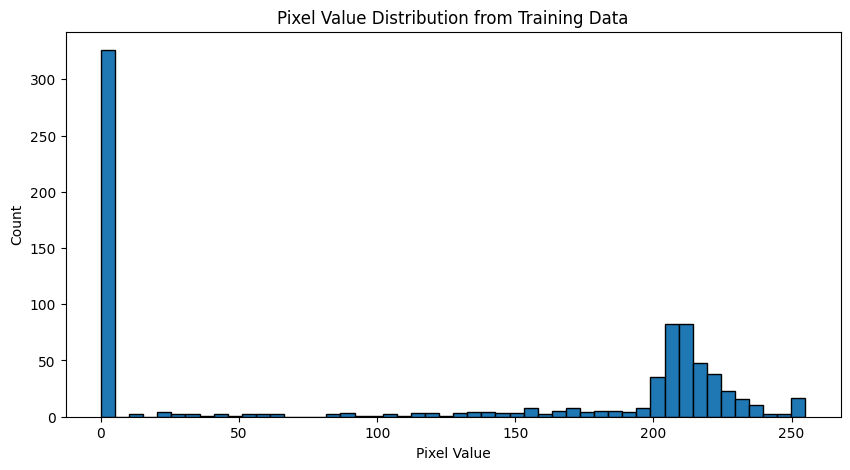

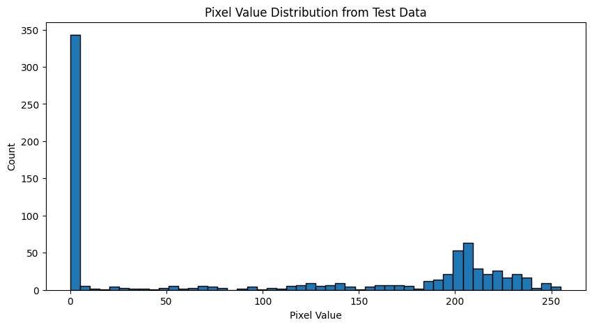

```python
# Pixel Distribution
# Plot the distribution of pixel values for training data
fig = plt.figure(figsize=(10, 5))
plt.hist(train_images[0], bins=50, edgecolor='black')
plt.title('Pixel Value Distribution from Training Data')
plt.xlabel('Pixel Value')
plt.ylabel('Count')
plt.show()

# Pixel Distribution
# Plot the distribution of pixel values for test data
fig = plt.figure(figsize=(10, 5))
plt.hist(test_images[0], bins=50, edgecolor='black')
plt.title('Pixel Value Distribution from Test Data')
plt.xlabel('Pixel Value')
plt.ylabel('Count')
plt.show()
```

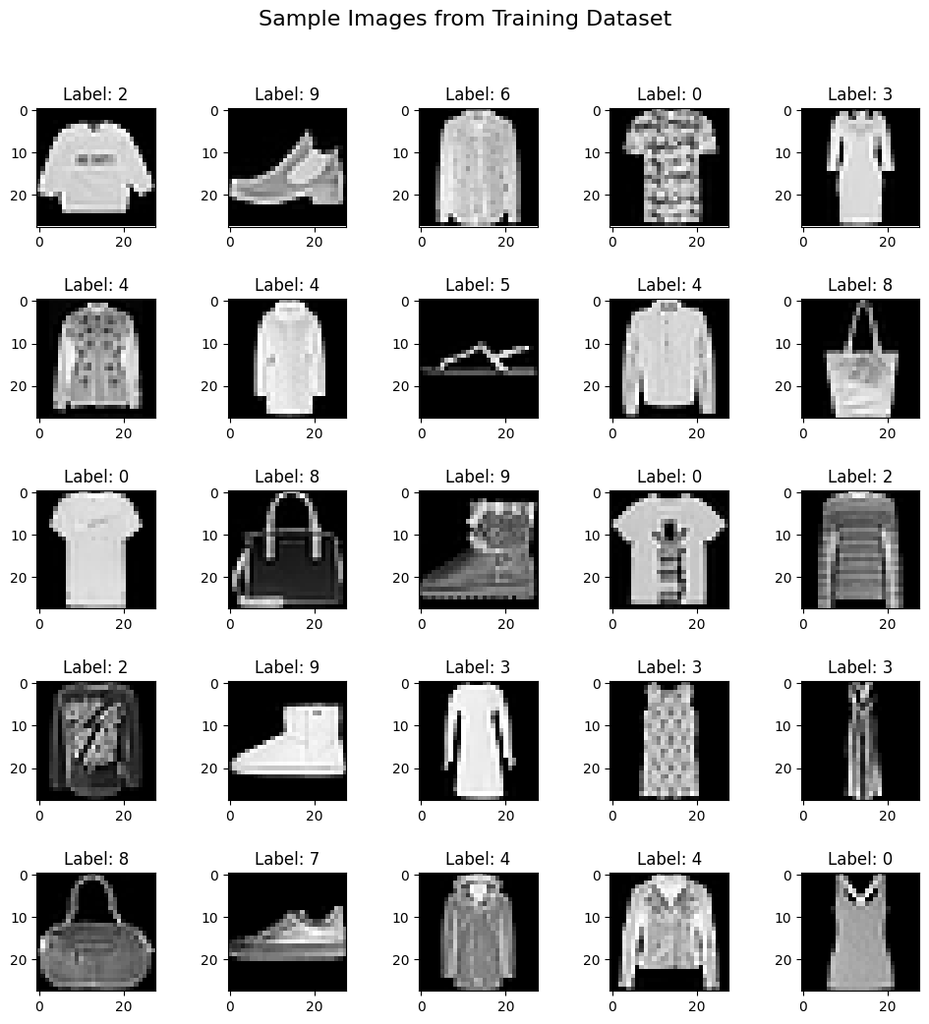

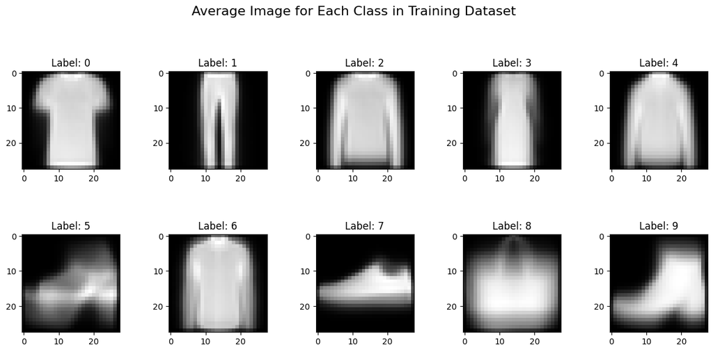

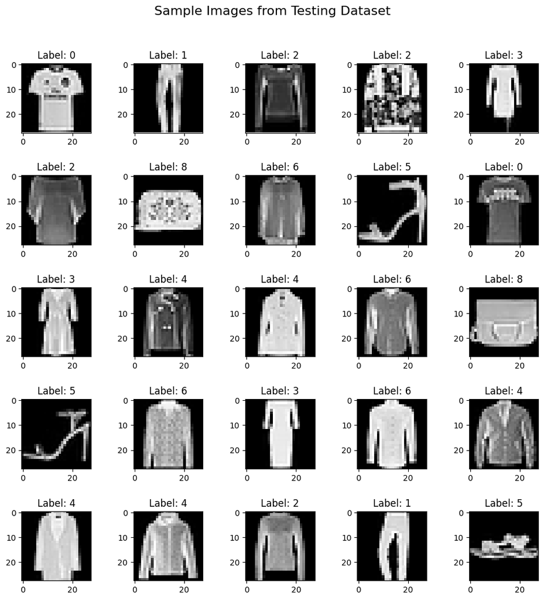

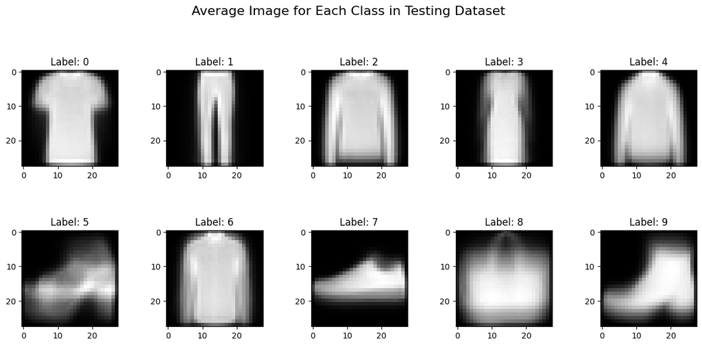

```python
# Define a function to perform EDA
def perform_eda(images, labels, dataset_name):
    # Display a sample of images
    fig, axes = plt.subplots(5, 5, figsize=(10,10))
    for i, ax in enumerate(axes.flat):
        ax.imshow(images[i].reshape(28, 28), cmap='gray')
        ax.set_title(f'Label: {labels[i]}')
    plt.tight_layout(pad=2.0)  # Increase padding
    plt.suptitle(f'Sample Images from {dataset_name}', fontsize=16, y=1.05)  # Adjust y position
    plt.show()

    # Display the average pixel value for each class
    fig, axes = plt.subplots(2, 5, figsize=(15,6))
    axes = axes.ravel()
    for i in np.arange(0, 10):
        axes[i].imshow(images[labels==i].mean(axis=0).reshape(28, 28), cmap='gray')
        axes[i].set_title(f'Label: {i}', fontsize=12)
    plt.subplots_adjust(wspace=0.5, hspace=0.5)  # Adjust horizontal and vertical spacing
    plt.suptitle(f'Average Image for Each Class in {dataset_name}', fontsize=16, y=1.05)  # Adjust y position
    plt.show()

# Perform EDA on the training dataset
perform_eda(train_images, train_labels, 'Training Dataset')

# Perform EDA on the testing dataset
perform_eda(test_images, test_labels, 'Testing Dataset')
```

## Data Preprocessing

We need to normalize the pixel values and convert the labels to categorical format.

```python
from tensorflow import keras

# Normalized the images
normalized_train_images = train_images / 255.0 #The reason we use 255.0 for normalization is because the pixel values of an
                                                # image are usually stored as 8-bit unsigned integers,
                                                # which means they can range from 0 (black) to 255 (white).
normalized_test_images = test_images / 255.0

# Converting labels to categorical
categorical_train_labels = keras.utils.to_categorical(train_labels)
categorical_test_labels = keras.utils.to_categorical(test_labels)
# Print the number of samples in the train set
print(f"Number of samples in the train set: {normalized_train_images.shape[0]}")

# Assuming we have a validation set split from the training set
validation_split = 0.2
num_validation_samples = int(validation_split * normalized_train_images.shape[0])
print(f"Number of samples in the validation set: {num_validation_samples}")

# Printing the shapes of the train and validation sets
num_train_samples = normalized_train_images.shape[0] - num_validation_samples
print(f"Train and validation shapes: {num_train_samples}, {num_validation_samples}")
```

```
Number of samples in the train set: 60000
Number of samples in the validation set: 12000
Train and validation shapes: 48000, 12000
```

## Defining 3 Different Neural Networks and Models

`Model 1:` Varies the number of neurons in the dense layer. This model has three dense layers with 1024, 512, and 256 neurons respectively.

`Model 2:` Adjusts the learning rate.

`Model 3:` Experiments with different activation functions in the dense layer. This model uses the sigmoid, tanh, and relu activation functions in its dense layers.

```python
import os
print(os.getcwd())
```

```
d:\Study\Machine Learning Foundation\Lab9
```

```python
import keras
from keras.layers import Dense, Input #Dense, Input: These are different types of layers that you can add to your neural network.
from keras.callbacks import ModelCheckpoint # ModelCheckpoint: This is used to save the model after every epoch.
from keras.layers import Reshape #Reshape: This is used to reshape the input to the desired shape.
from keras.layers import Flatten #Flatten: This is used to flatten the input.

# Defined three different models
model1 = keras.Sequential([
    Input(shape=(784,)),
    Reshape((28, 28)),
    Flatten(),
    Dense(1024, activation='relu'),
    Dense(512, activation='relu'),
    Dense(256, activation='relu'),
    Dense(10, activation='softmax')
])

model2 = keras.Sequential([
    Input(shape=(784,)),
    Reshape((28, 28)),
    Flatten(),
    Dense(512, activation='relu'),
    Dense(256, activation='relu'),
    Dense(128, activation='relu'),
    Dense(10, activation='softmax')
])

model3 = keras.Sequential([
    Input(shape=(784,)),
    Reshape((28, 28)),
    Flatten(),
    Dense(512, activation='sigmoid'),
    Dense(256, activation='tanh'),
    Dense(128, activation='relu'),
    Dense(10, activation='softmax')
])

# Compiling the models

# We use the Adam optimizer for all models. Adam is a popular choice because it combines the advantages of two other extensions of stochastic gradient descent:
# 1. Adaptive Gradient Algorithm (AdaGrad) that maintains a per-parameter learning rate that improves performance on problems with sparse gradients
# 2. Root Mean Square Propagation (RMSProp) that also maintains per-parameter learning rates that are adapted based on the average of recent magnitudes of the gradients for the weight.
# Adam realizes the benefits of both AdaGrad and RMSProp.
# The loss function is categorical crossentropy, which is suitable for multi-class classification problems.
# The metric used to evaluate the model is accuracy.
model1.compile(optimizer='adam', loss='categorical_crossentropy', metrics=['accuracy'])
model2.compile(optimizer=keras.optimizers.Adam(learning_rate=0.01), loss='categorical_crossentropy', metrics=['accuracy'])
model3.compile(optimizer='adam', loss='categorical_crossentropy', metrics=['accuracy'])

# Define the checkpoint to save the best weights
checkpoint1 = ModelCheckpoint('model1_best_weights.weights.h5', save_best_only=True, monitor='val_loss', mode='min', save_weights_only=True)
checkpoint2 = ModelCheckpoint('model2_best_weights.weights.h5', save_best_only=True, monitor='val_loss', mode='min', save_weights_only=True)
checkpoint3 = ModelCheckpoint('model3_best_weights.weights.h5', save_best_only=True, monitor='val_loss', mode='min', save_weights_only=True)
```

## Modeling

Let's train the model.

```python
# Training the models and saving it in the history for later use
history1 = model1.fit(normalized_train_images, categorical_train_labels, epochs=2, batch_size=100, validation_split=0.2, callbacks=[checkpoint1])
history2 = model2.fit(normalized_train_images, categorical_train_labels, epochs=3, batch_size=100, validation_split=0.2, callbacks=[checkpoint2])
history3 = model3.fit(normalized_train_images, categorical_train_labels, epochs=2, batch_size=100, validation_split=0.2, callbacks=[checkpoint3])
```

```
480/480 ━━━━━━━━━━━━━━━━━━━━ 14s 25ms/step - accuracy: 0.7693 - loss: 0.6438 - val_accuracy: 0.8572 - val_loss: 0.4043
480/480 ━━━━━━━━━━━━━━━━━━━━ 11s 24ms/step - accuracy: 0.8602 - loss: 0.3797 - val_accuracy: 0.8574 - val_loss: 0.3912
480/480 ━━━━━━━━━━━━━━━━━━━━ 9s 14ms/step - accuracy: 0.6988 - loss: 1.0852 - val_accuracy: 0.8160 - val_loss: 0.4893
480/480 ━━━━━━━━━━━━━━━━━━━━ 7s 15ms/step - accuracy: 0.8435 - loss: 0.4250 - val_accuracy: 0.8499 - val_loss: 0.4064
480/480 ━━━━━━━━━━━━━━━━━━━━ 6s 12ms/step - accuracy: 0.8617 - loss: 0.3841 - val_accuracy: 0.8565 - val_loss: 0.4031
480/480 ━━━━━━━━━━━━━━━━━━━━ 8s 13ms/step - accuracy: 0.7060 - loss: 0.8309 - val_accuracy: 0.8385 - val_loss: 0.4444
480/480 ━━━━━━━━━━━━━━━━━━━━ 10s 12ms/step - accuracy: 0.8452 - loss: 0.4205 - val_accuracy: 0.8589 - val_loss: 0.3927
```

## Choosing Best Model out of 3 Models

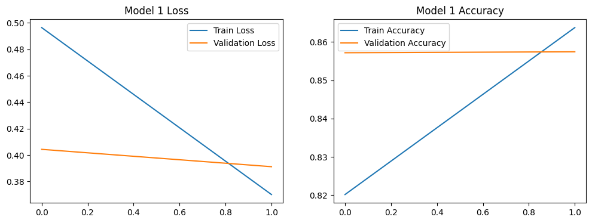

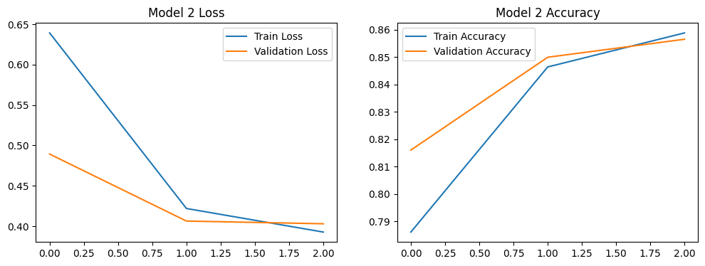

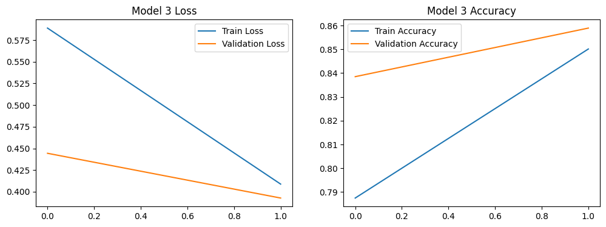

```python
# Ploting the training and validation loss and accuracy for each model
for i, history in enumerate([history1, history2, history3], start=1):
    plt.figure(figsize=(12, 4))
    plt.subplot(1, 2, 1)
    plt.plot(history.history['loss'], label='Train Loss')
    plt.plot(history.history['val_loss'], label='Validation Loss')
    plt.title(f'Model {i} Loss')
    plt.legend()

    plt.subplot(1, 2, 2)
    plt.plot(history.history['accuracy'], label='Train Accuracy')
    plt.plot(history.history['val_accuracy'], label='Validation Accuracy')
    plt.title(f'Model {i} Accuracy')
    plt.legend()

    plt.show()
```

`Model 1:`

Model 1 demonstrates commendable consistency, with the training loss decreasing steadily and the validation loss remaining relatively flat. The model's accuracy is impressive, showing steady gains in the training accuracy with the validation accuracy maintaining a consistent trajectory. No overfitting is evident within the epoch range provided.

`General Observations:`

The models are effectively learning from the data, with each displaying unique tendencies that highlight their strengths and areas for optimization.

```python
# Loaded the best weights for each model
model1.load_weights('D:/Study/Machine Learning Foundation/Lab9/model1_best_weights.weights.h5')
model2.load_weights('D:/Study/Machine Learning Foundation/Lab9/model2_best_weights.weights.h5')
model3.load_weights('D:/Study/Machine Learning Foundation/Lab9/model3_best_weights.weights.h5')

# Evaluating the models
score1 = model1.evaluate(normalized_test_images, categorical_test_labels)
score2 = model2.evaluate(normalized_test_images, categorical_test_labels)
score3 = model3.evaluate(normalized_test_images, categorical_test_labels)

print(f'Model 1 Test Loss: {score1[0]}, Test Accuracy: {score1[1]}')
print(f'Model 2 Test Loss: {score2[0]}, Test Accuracy: {score2[1]}')
print(f'Model 3 Test Loss: {score3[0]}, Test Accuracy: {score3[1]}')
```

```
313/313 ━━━━━━━━━━━━━━━━━━━━ 1s 3ms/step - accuracy: 0.8617 - loss: 0.3849
313/313 ━━━━━━━━━━━━━━━━━━━━ 1s 2ms/step - accuracy: 0.8546 - loss: 0.4021
313/313 ━━━━━━━━━━━━━━━━━━━━ 1s 2ms/step - accuracy: 0.8576 - loss: 0.3911
Model 1 Test Loss: 0.3785701394081116, Test Accuracy: 0.8644999861717224
Model 2 Test Loss: 0.39698466658592224, Test Accuracy: 0.859499990940094
Model 3 Test Loss: 0.3877212703227997, Test Accuracy: 0.859499990940094
```

Based on the test loss and test accuracy provided for the three models, `Model 1 is the best performer.`

Model 1 has the lowest test loss, which means it makes fewer mistakes on new, unseen data compared to Models 2 and 3. A lower loss typically indicates a model that is better at generalizing from its training.

Model 1 also has the highest test accuracy, suggesting it correctly labels new data more often than the other two models. Higher accuracy is generally the goal, as it means the model's predictions are reliable more often.

So, Model 1 strikes the best balance between making few errors and making correct predictions on data it hasn't seen before, which is what we look for in a robust model.

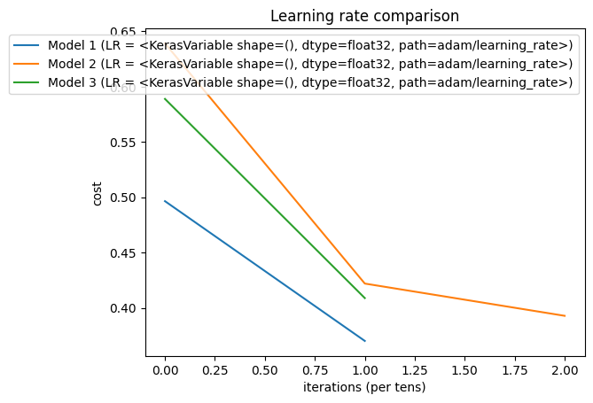

```python
# Getting the learning rates
learning_rate1 = model1.optimizer.learning_rate
learning_rate2 = model2.optimizer.learning_rate
learning_rate3 = model3.optimizer.learning_rate

# Getting the cost values
costs1 = history1.history['loss']
costs2 = history2.history['loss']
costs3 = history3.history['loss']

# Plotting the costs
plt.plot(np.squeeze(costs1), label="Model 1 (LR = " + str(learning_rate1) + ")")
plt.plot(np.squeeze(costs2), label="Model 2 (LR = " + str(learning_rate2) + ")")
plt.plot(np.squeeze(costs3), label="Model 3 (LR = " + str(learning_rate3) + ")")

plt.ylabel('cost')
plt.xlabel('iterations (per tens)')
plt.title("Learning rate comparison")
plt.legend()
plt.show()
```

In graph, All three models are getting better over time because the cost (how much the model is getting wrong) is going down.

Model 3 is right in the middle—not too fast, not too slow.

## Evaluation :

We choose Model 1 as our Best Model

```python
from sklearn.metrics import accuracy_score, precision_score, recall_score, f1_score

# Assuming that your validation data is stored in the variables `normalized_test_images` and `test_labels`

# Making predictions
predictions = model1.predict(normalized_test_images)
predictions = np.argmax(predictions, axis=1)

# Reshape predictions array to match the shape of test_labels
predictions = predictions[:20]  # Assuming you want to match the first 20 samples
predictions = np.reshape(predictions, (20,))

# Calculating metrics
accuracy = accuracy_score(test_labels, predictions)
precision = precision_score(test_labels, predictions, average='weighted')
recall = recall_score(test_labels, predictions, average='weighted')
f1 = f1_score(test_labels, predictions, average='weighted')

print(f'Accuracy: {accuracy}')
print(f'Precision: {precision}')
print(f'Recall: {recall}')
print(f'F1 Score: {f1}')
```

[output not shown]

```python
# Let's do prediction on some of the test set samples
test_samples = normalized_test_images[:20]
test_labels = test_labels[:20]

# Predicting the labels for each model
prob1 = model1.predict(test_samples)
predicted_labels1 = np.argmax(prob1, axis=1)

print("True labels:     ", test_labels.tolist())
print("Predicted labels Model 1: ", predicted_labels1.tolist())
```

```
1/1 ━━━━━━━━━━━━━━━━━━━━ 0s 37ms/step
True labels:      [0, 1, 2, 2, 3, 2, 8, 6, 5, 0, 3, 4, 4, 6, 8, 5, 6, 3, 6, 4]
Predicted labels Model 1:  [0, 1, 2, 2, 4, 6, 8, 4, 5, 0, 3, 2, 4, 6, 8, 5, 6, 3, 6, 4]
```

By comparing the true labels to the predicted labels from Model 1, Model 1 gets most of the predictions correct.

Overall, Model 1 shows strong predictive abilities, but it may benefit from further training. Its accuracy aligns with the test accuracy provided, supporting the choice of Model 1 as the best model among the three.

[figure not shown]

```python
# Let's visualize the results
f, ax = plt.subplots(1,10, figsize=(20,5))

for i in range(10):
    img = test_samples[i].reshape(28,28)
    ax[i].imshow(img, cmap='gray')
    ax[i].axis('off')
    ax[i].set_title("Model 1: " + labels[predicted_labels1[i]])
plt.show()
```

## Conclusion

We started with exploration and classification task on the Fashion-MNIST dataset. Then, in beginning with retrieving the dataset and embarking on a comprehensive Exploratory Data Analysis (EDA). The EDA phase allowed us to scrutinize various clothing items within the dataset, unveiling unique characteristics and challenges.

Upon these insights, we crafted and trained three distinct fully connected feedforward neural network models using Keras, each designed to decipher the patterns ingrained within the fMNIST dataset effectively.

Model 1 emerged as the superior contender upon testing, demonstrating the lowest loss and highest accuracy. This model achieved an equilibrium between learning from the training data and generalizing to unseen data, showcasing its robustness.

The transition from Lab 8 to Lab 9, marked by introducing multiple models for comparative evaluation, facilitated an iterative enhancement of our methodology. By the conclusion of Lab 9, we had identified the most efficacious model through empirical evidence and acquired substantial expertise in neural network optimization.

Wrapping it all up, this whole lab was about taking a step-by-step approach to machine learning. Starting with a deep-dive EDA, picking the right models, training them up, and then putting them through the wringer with some tough testing. The big takeaway? We've got a solid neural network model that's all set for taking on more image classification challenges down the road.

## What if we wanted to increase the precision for class '5', how can we do that without changing the model or retraining? provide code that exemplifies this.

```python
# Defined a function to predict with a threshold
def predict_with_threshold(probabilities, threshold=0.3):
  predicted_labels = np.argmax(probabilities, axis=1)
  for i in range(len(predicted_labels)):
    if probabilities[i, 5] > threshold:  # Check probability for class '5' only
      predicted_labels[i] = 5  # Set prediction to class '5' if probability exceeds threshold
  return predicted_labels

# Calculated metrics using the threshold for class '5'
predictions_threshold = predict_with_threshold(neural_network_model.predict(normalized_test_images[:20]))
precision_threshold = precision_score(test_labels[:20], predictions_threshold, average='weighted')
print(f'\nMetrics with Threshold for Class 5:')
print(f'Precision (weighted): {precision_threshold}')
```

[output not shown]

## What if we wanted to increase the recall for class '5', how can we do that without changing the model or retraining? provide code that exemplifies this.

To increase the recall for class '5' without changing the model or retraining, we can adjust the decision threshold for this specific class 5. By default, the decision threshold is 0.5 for multi-class classification problems. If the predicted probability for a class is greater than or equal to this threshold, the instance is classified as that class.

```python
def adjust_threshold_for_recall(probabilities, class_index, new_threshold):
    # Create a new array for adjusted predictions
    adjusted_predictions_recall = np.zeros(probabilities.shape[0])

    # Classify instances where the probability of class '5' is greater than the new threshold as class '5'
    adjusted_predictions_recall[probabilities[:, class_index] > new_threshold] = class_index

    # For other instances, classify as the class with the highest probability
    adjusted_predictions_recall[probabilities[:, class_index] <= new_threshold] = np.argmax(probabilities[probabilities[:, class_index] <= new_threshold], axis=1)

    return adjusted_predictions_recall

# Predict the probabilities for the first 20 test images
probabilities_recall = neural_network_model.predict(normalized_test_images[:20])

# Adjust the decision threshold for class '5' to increase recall
predictions_for_recall = adjust_threshold_for_recall(probabilities_recall, 5, 0.5)

# Calculate the recall score for the adjusted predictions
recall_adjusted = recall_score(test_labels[:20], predictions_for_recall, average='weighted')

print(f'\nMetrics with Threshold for Class 5:')
print(f'Recall (weighted): {recall_adjusted:.4f}')
```

[output not shown]

## References :

Class Notebook : https://github.com/CSCN8010/CSCN8010/blob/main/dl_class_notebooks/03A_minimal_mnist_keras.ipynb

https://github.com/CSCN8010/CSCN8010/blob/main/dl_class_notebooks/03D_keras_checkpoints_save_model.ipynb

https://github.com/CSCN8010/CSCN8010/blob/main/class_notebooks/datasets/mnist.ipynb

Kaggle kutubkapadia: https://www.kaggle.com/code/kutubkapadia/fashion-mnist-with-tensorflow

Kaggle jaeseung17 : https://www.kaggle.com/code/jaeseung17/fmnist-dataset-with-cnns-tensorflow

Kaggle aakashnain https://www.kaggle.com/code/aakashnain/eagerfmnist